# Notebook

#### GreedyGame Data Analyst Assignment- Solutions

#### Importing Libraries

```python
import pandas as pd
import numpy as np
import matplotlib.pyplot as plt
import seaborn as sns
```

```python
df= pd.read_csv("sample_data_set_2 - Sheet1 (1).csv",sep=",") #Uploading dataset
```

```python
df.head()
```

|  | Date | App | Ad Group | State | Revenue | Ad Requests | Ad Responses | Fill Rate | Impressions | Render Rate | 1st Clicks | 2nd Clicks |
| --- | --- | --- | --- | --- | --- | --- | --- | --- | --- | --- | --- | --- |
| 0 | 08 Sep 2020 | (SDK X) Cricket Mazza | Cricket Mazza Banner (AdX) | Unresolved | 0.0 | 3932330 | 3926253 | 99.9% | 3849749 | 98.1% | 10199 | 0 |
| 1 | 08 Sep 2020 | (SDK X) Cricket Mazza | 320x50 | Unresolved | 0.0 | 3932330 | 119 | 99.9% | 118 | 99.2% | 2 | 2 |
| 2 | 08 Sep 2020 | (SDK X) Cricket Mazza | Dream11_320x50 | Unresolved | 0.0 | 3932330 | 96 | 99.9% | 93 | 96.9% | 2 | 2 |
| 3 | 08 Sep 2020 | (SDK X) Cricket Mazza | My11_320x50 | Unresolved | 0.0 | 3932330 | 111 | 99.9% | 110 | 99.1% | 2 | 2 |
| 4 | 06 Sep 2020 | (SDK X) Cricket Mazza | Cricket Mazza Banner (AdX) | Unresolved | 0.0 | 3839002 | 3834328 | 99.9% | 3785127 | 98.7% | 9492 | 0 |

```python
df.info()
```

```
<class 'pandas.core.frame.DataFrame'>
RangeIndex: 48293 entries, 0 to 48292
Data columns (total 12 columns):
 #   Column        Non-Null Count  Dtype
---  ------        --------------  -----
 0   Date          48293 non-null  object
 1   App           48270 non-null  object
 2   Ad Group      44300 non-null  object
 3   State         48293 non-null  object
 4   Revenue       48293 non-null  float64
 5   Ad Requests   48293 non-null  int64
 6   Ad Responses  48293 non-null  int64
 7   Fill Rate     48293 non-null  object
 8   Impressions   48293 non-null  int64
 9   Render Rate   48293 non-null  object
 10  1st Clicks    48293 non-null  int64
 11  2nd Clicks    48293 non-null  int64
dtypes: float64(1), int64(5), object(6)
memory usage: 4.4+ MB
```

```python
df.dtypes
```

```
Date             object
App              object
Ad Group         object
State            object
Revenue         float64
Ad Requests       int64
Ad Responses      int64
Fill Rate        object
Impressions       int64
Render Rate      object
1st Clicks        int64
2nd Clicks        int64
dtype: object
```

```python
df.isnull().sum() #Missing Values Column-wise
```

```
Date               0
App               23
Ad Group        3993
State              0
Revenue            0
Ad Requests        0
Ad Responses       0
Fill Rate          0
Impressions        0
Render Rate        0
1st Clicks         0
2nd Clicks         0
dtype: int64
```

```python
df.isnull().sum().sum() #Total Missing Values
```

```
4016
```

#### Dropping Missing Values

```python
df= df.dropna()
```

```python
df.corr()
```

|  | Revenue | Ad Requests | Ad Responses | Impressions | 1st Clicks | 2nd Clicks |
| --- | --- | --- | --- | --- | --- | --- |
| Revenue | 1.000000 | 0.127370 | 0.220613 | 0.192691 | 0.332629 | 0.329001 |
| Ad Requests | 0.127370 | 1.000000 | 0.330752 | 0.321995 | 0.193078 | 0.238182 |
| Ad Responses | 0.220613 | 0.330752 | 1.000000 | 0.996202 | 0.435179 | 0.400689 |
| Impressions | 0.192691 | 0.321995 | 0.996202 | 1.000000 | 0.416792 | 0.376401 |
| 1st Clicks | 0.332629 | 0.193078 | 0.435179 | 0.416792 | 1.000000 | 0.634154 |
| 2nd Clicks | 0.329001 | 0.238182 | 0.400689 | 0.376401 | 0.634154 | 1.000000 |

```python
df['App'].nunique() #116 Unique Apps
```

```
116
```

```python
df.head()
```

|  | Date | App | Ad Group | State | Revenue | Ad Requests | Ad Responses | Fill Rate | Impressions | Render Rate | 1st Clicks | 2nd Clicks |
| --- | --- | --- | --- | --- | --- | --- | --- | --- | --- | --- | --- | --- |
| 0 | 08 Sep 2020 | (SDK X) Cricket Mazza | Cricket Mazza Banner (AdX) | Unresolved | 0.0 | 3932330 | 3926253 | 99.9% | 3849749 | 98.1% | 10199 | 0 |
| 1 | 08 Sep 2020 | (SDK X) Cricket Mazza | 320x50 | Unresolved | 0.0 | 3932330 | 119 | 99.9% | 118 | 99.2% | 2 | 2 |
| 2 | 08 Sep 2020 | (SDK X) Cricket Mazza | Dream11_320x50 | Unresolved | 0.0 | 3932330 | 96 | 99.9% | 93 | 96.9% | 2 | 2 |
| 3 | 08 Sep 2020 | (SDK X) Cricket Mazza | My11_320x50 | Unresolved | 0.0 | 3932330 | 111 | 99.9% | 110 | 99.1% | 2 | 2 |
| 4 | 06 Sep 2020 | (SDK X) Cricket Mazza | Cricket Mazza Banner (AdX) | Unresolved | 0.0 | 3839002 | 3834328 | 99.9% | 3785127 | 98.7% | 9492 | 0 |

#### heatmap

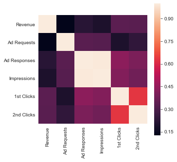

```python
sns.set_style(style = "white")
corr = df.corr()

mask = np.triu(np.ones_like(corr, dtype=bool))

f,ax = plt.subplots(figsize=(5,5))

#cmap = sns.diverging_palette(230,20)

sns.heatmap(corr, square = True)
```

```python
df.corr()
```

|  | Revenue | Ad Requests | Ad Responses | Impressions | 1st Clicks | 2nd Clicks |
| --- | --- | --- | --- | --- | --- | --- |
| Revenue | 1.000000 | 0.127370 | 0.220613 | 0.192691 | 0.332629 | 0.329001 |
| Ad Requests | 0.127370 | 1.000000 | 0.330752 | 0.321995 | 0.193078 | 0.238182 |
| Ad Responses | 0.220613 | 0.330752 | 1.000000 | 0.996202 | 0.435179 | 0.400689 |
| Impressions | 0.192691 | 0.321995 | 0.996202 | 1.000000 | 0.416792 | 0.376401 |
| 1st Clicks | 0.332629 | 0.193078 | 0.435179 | 0.416792 | 1.000000 | 0.634154 |
| 2nd Clicks | 0.329001 | 0.238182 | 0.400689 | 0.376401 | 0.634154 | 1.000000 |

#### 3. Also, if we see 1st Clicks & 2nd clicks have 63% correlation meaning users tend to interact more after 1st clicks to know more about an ad.

```python
df['Revenue'].value_counts()/len(df)
```

```
0.00    0.868261
0.01    0.033787
0.02    0.013732
0.03    0.007995
0.04    0.005962
          ...
9.11    0.000023
2.42    0.000023
3.14    0.000023
6.54    0.000023
7.98    0.000023
Name: Revenue, Length: 364, dtype: float64
```

#### Around 86% of data has 0 OR No Revenue for that particular period of time.

```python
df.head()
```

|  | Date | App | Ad Group | State | Revenue | Ad Requests | Ad Responses | Fill Rate | Impressions | Render Rate | 1st Clicks | 2nd Clicks |
| --- | --- | --- | --- | --- | --- | --- | --- | --- | --- | --- | --- | --- |
| 0 | 08 Sep 2020 | (SDK X) Cricket Mazza | Cricket Mazza Banner (AdX) | Unresolved | 0.0 | 3932330 | 3926253 | 99.9% | 3849749 | 98.1% | 10199 | 0 |
| 1 | 08 Sep 2020 | (SDK X) Cricket Mazza | 320x50 | Unresolved | 0.0 | 3932330 | 119 | 99.9% | 118 | 99.2% | 2 | 2 |
| 2 | 08 Sep 2020 | (SDK X) Cricket Mazza | Dream11_320x50 | Unresolved | 0.0 | 3932330 | 96 | 99.9% | 93 | 96.9% | 2 | 2 |
| 3 | 08 Sep 2020 | (SDK X) Cricket Mazza | My11_320x50 | Unresolved | 0.0 | 3932330 | 111 | 99.9% | 110 | 99.1% | 2 | 2 |
| 4 | 06 Sep 2020 | (SDK X) Cricket Mazza | Cricket Mazza Banner (AdX) | Unresolved | 0.0 | 3839002 | 3834328 | 99.9% | 3785127 | 98.7% | 9492 | 0 |

#### To increase overall revenue of the apps, we can Raise the prices or Increase our customer base.

#### As mentioned earlier, around 86% of data has 0 revenue. If we can focus on these Apps it can improve the overall revenue.

#### 2. Are there any discrepancies in the data set shared with you? What are the possible reasons for such mismatch?

```python
###Fill Rate--> % of Ad Responses on Ad Requests
###Render Rate--> % of Impressions on Ad Responses
```

```python
df.head(15)
```

|  | Date | App | Ad Group | State | Revenue | Ad Requests | Ad Responses | Fill Rate | Impressions | Render Rate | 1st Clicks | 2nd Clicks |
| --- | --- | --- | --- | --- | --- | --- | --- | --- | --- | --- | --- | --- |
| 0 | 08 Sep 2020 | (SDK X) Cricket Mazza | Cricket Mazza Banner (AdX) | Unresolved | 0.00 | 3932330 | 3926253 | 99.9% | 3849749 | 98.1% | 10199 | 0 |
| 1 | 08 Sep 2020 | (SDK X) Cricket Mazza | 320x50 | Unresolved | 0.00 | 3932330 | 119 | 99.9% | 118 | 99.2% | 2 | 2 |
| 2 | 08 Sep 2020 | (SDK X) Cricket Mazza | Dream11_320x50 | Unresolved | 0.00 | 3932330 | 96 | 99.9% | 93 | 96.9% | 2 | 2 |
| 3 | 08 Sep 2020 | (SDK X) Cricket Mazza | My11_320x50 | Unresolved | 0.00 | 3932330 | 111 | 99.9% | 110 | 99.1% | 2 | 2 |
| 4 | 06 Sep 2020 | (SDK X) Cricket Mazza | Cricket Mazza Banner (AdX) | Unresolved | 0.00 | 3839002 | 3834328 | 99.9% | 3785127 | 98.7% | 9492 | 0 |
| 5 | 06 Sep 2020 | (SDK X) Cricket Mazza | 320x50 | Unresolved | 0.00 | 3839002 | 101 | 99.9% | 101 | 100% | 0 | 0 |
| 6 | 06 Sep 2020 | (SDK X) Cricket Mazza | Dream11_320x50 | Unresolved | 0.00 | 3839002 | 126 | 99.9% | 121 | 96.0% | 1 | 1 |
| 7 | 06 Sep 2020 | (SDK X) Cricket Mazza | My11_320x50 | Unresolved | 0.00 | 3839002 | 115 | 99.9% | 111 | 96.5% | 1 | 1 |
| 8 | 06 Sep 2020 | Callbreak Multiplayer | Rummy77 | Uttar Pradesh | 0.00 | 3702040 | 245485 | 100% | 227097 | 92.5% | 1464 | 410 |
| 9 | 06 Sep 2020 | Callbreak Multiplayer | New creative | Uttar Pradesh | 1.32 | 3702040 | 246124 | 100% | 227170 | 92.3% | 1583 | 396 |
| 10 | 06 Sep 2020 | Callbreak Multiplayer | creative_aug | Uttar Pradesh | 0.66 | 3702040 | 245981 | 100% | 227060 | 92.3% | 1535 | 369 |
| 11 | 06 Sep 2020 | Callbreak Multiplayer | Nov New | Uttar Pradesh | 2.64 | 3702040 | 245851 | 100% | 226895 | 92.3% | 1452 | 365 |
| 12 | 06 Sep 2020 | Callbreak Multiplayer | revshare | Uttar Pradesh | 0.00 | 3702040 | 5 | 100% | 4 | 80.00% | 0 | 0 |
| 13 | 06 Sep 2020 | Callbreak Multiplayer | Rooter_Callbreak | Uttar Pradesh | 0.52 | 3702040 | 190575 | 100% | 177858 | 93.3% | 1064 | 1049 |
| 14 | 06 Sep 2020 | Callbreak Multiplayer | Callbreak Multiplayer2_Inmobi_No Floor | Uttar Pradesh | 1.37 | 3702040 | 18797 | 100% | 14648 | 77.93% | 384 | 120 |

```python
###Fill Rate--> % of Ad Responses on Ad Requests
###Render Rate--> % of Impressions on Ad Responses
```

#### There are few discrepancies or fault information in column Fill Rate

```python
#### For Instance, Lets look for few rows.
#index- 13
190575/3702040
```

```
0.05147837408563927
```

```python
#index-14
18797/3702040
```

```
0.005077470799883308
```

```python
245485/3702040
```

```
0.06631073678296291
```

```python
245981/3702040
```

```
0.06644471696686151
```

#### So, these are just few samples but there're many other discrepancies in data. Reason is simple, just a miscalculation.